# Design & Analysis workshop

Priscila López-Beltrán Forcada

Spring 2021

In this session, we will learn the basics of **simple and multiple linear regression** First of all, what *is* regression analysis?

### The very basics of regression

Regression models attempt to make educated guesses about ‘hidden’ underlying parameters (which correspond to properties of interest in the real world) based on observable data

Simply put, this method is used to predict a quantitative outcome y on the basis of one single predictor variable x. The goal is to build a mathematical model (or formula) that defines y as a function of the x variable.

The mathematical formula of the linear regression can be written as: y = b0 + b1*x + e

Let’s visualize it

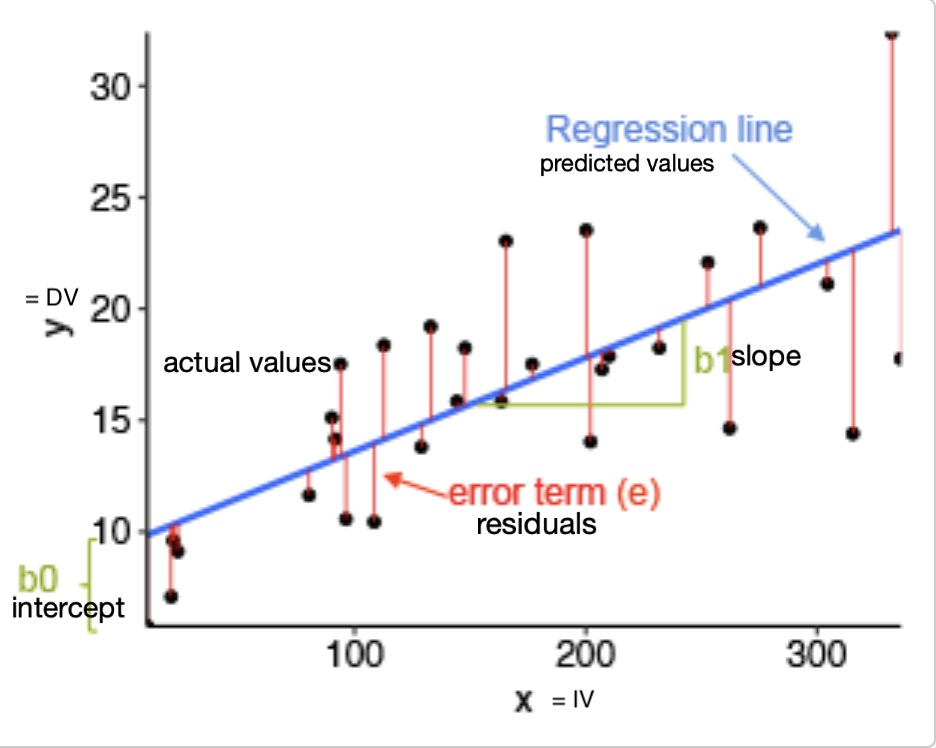

With multiple regression, the formula is the same, it just includes as many IVs as necessary and the regression lines in the graph will reflect that:

- Y = b0 + b1X1 + b2X2 + …………………… + bkXk

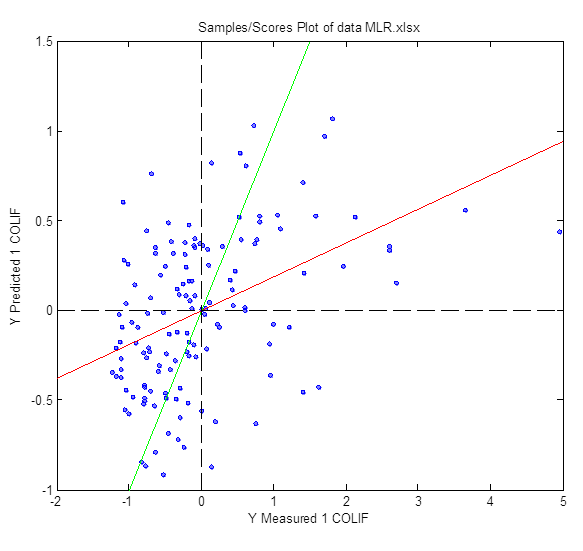

#### Assumptions in regression

In statistical analyses, all parametric tests assume some certain characteristic about the data, also known as *assumptions*. Violation of these assumptions changes the conclusion of the research and interpretation of the results.

**1. Normality of distribution of data and residuals** Mean, median and mode have the same value and it can be defined with just two parameters: mean and variance.

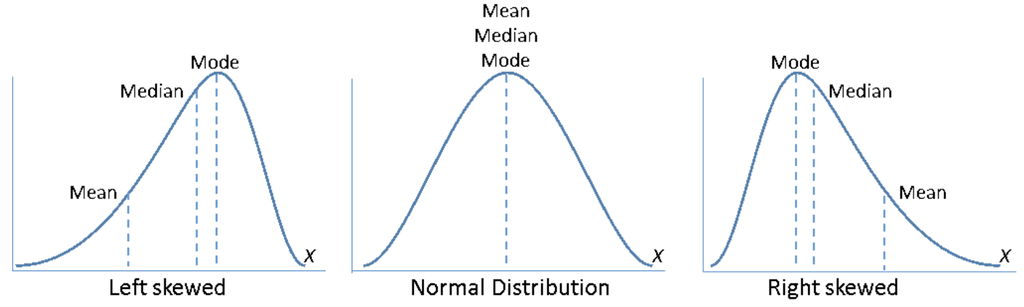

**2. Homogeneity of variance of residuals**

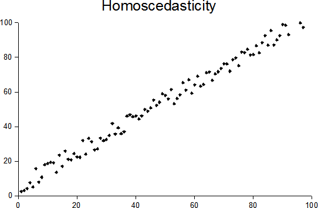

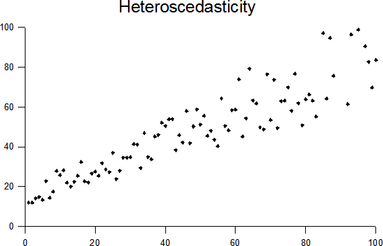

**3. Independence of residuals**

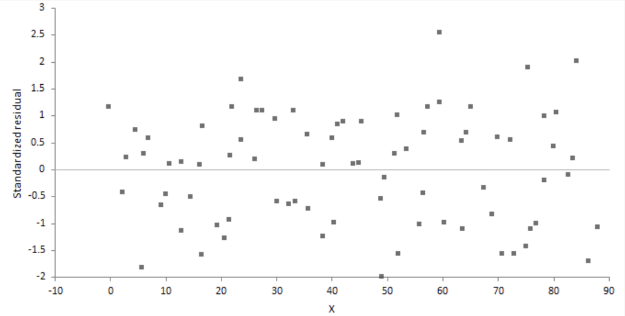

**4. Linearity**

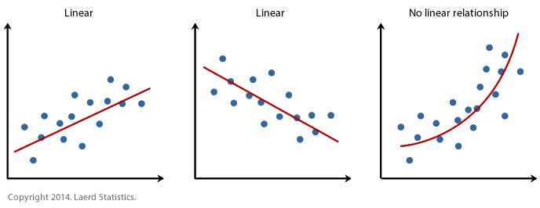

Let’s look at some real data:

We have a 2x2, repeated measures experiment where we want to test if there are differences in the processing of active and passive sentences depending on information structure. These are our conditions:

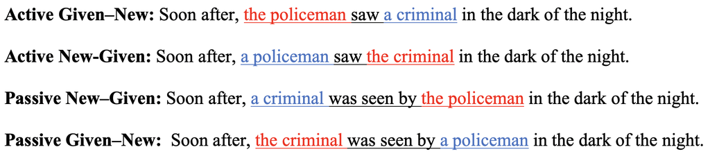

Given prior literature we can make the following predictions:

1. Actives will be read faster than passives
2. Given-New will be read faster than New-Given
3. Passive New-Given will be the most costly condition (slowest RTs)
4. There might be a positive correlation between proficiency (Picture Naming) and RTs

Let’s visualize it, does the graph seem to meet the predictions?

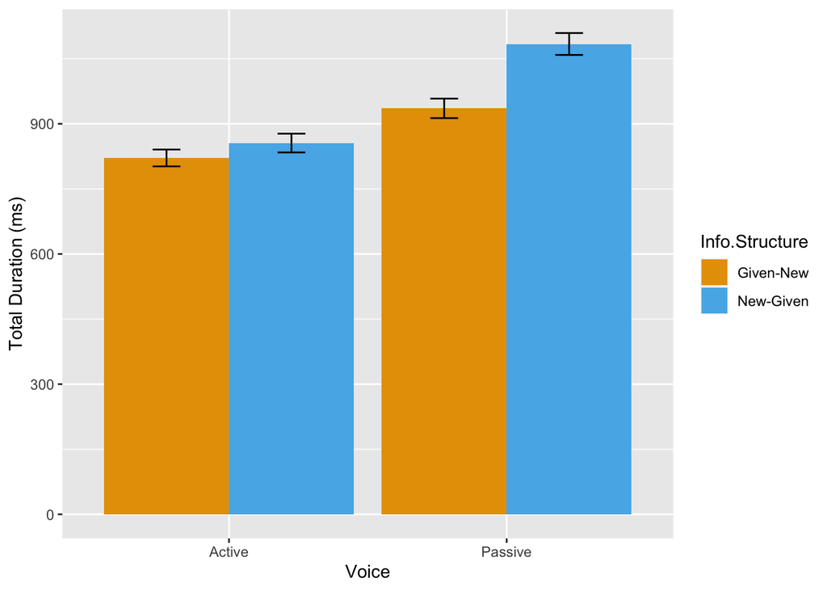

### Data preparation: Coding and centering categorical variables

It is common practice to code and center categorical variables (i.e.,factors) in order to help models converge. However, why exactly do we do this?

1. First, an advantage of coded variables is that even though they are technically nominal-level variables, we can treat them statistically like interval-level (i.e., continuous) variables.
2. Second, they enable us to include *both* levels of a variable into the *same* model by testing the variable as if it were continuous.
3. Third, it makes model parameters more interpretable.

There are several ways of coding variables, and the method we use will impact the interpretation of the intercept term and all other tests conducted. Here we will learn about the two main coding schemes:

#### Dummy coding

The simplest form of coding is called dummy coding (also called *treatment coding*) and the default in R. *This form of coding compares the mean of each category, to the mean of a baseline*. Thus, the coefficient of each dummy variable will be equal to the difference between the mean of the dummy variable and the baseline/reference group (i.e., intercept). It is very important to consider that dummy variables *are not independent* because they use the same reference level to determine significance, as such, they reflect only *simple effects*, that is, the effect of of one variable at one level of another variable.

For example: the intercept is the mean of “Active + Given-New” and we compare the other conditions to this.

#### Sum coding

Also called *effect coding*, in this form of coding, the intercept is equal to the grand mean of all conditions. *Thus, the coefficient of each of the variables is equal to the difference between the mean of the coded variables and the grand mean.* In contrast to dummy schemes, sum coding reflects the *main effects*, the effect of one variable independently of the others. This yields more interpretable parameters and interaction terms.

Importantly, this coding scheme can be used even with imbalances in the number of data point per condition created as a by-product of the cleaning process. Let’s see our data grouped by the IV *voice* for example:

```
##      Var1 Freq
## 1  Active  818
## 2 Passive  798
```

We obviously do not have the same number of observations per condition, what do we do?

First we make sure that all binary variables are two-level factors in vector form:

```r
monolingual_data_clean$cvoice <- ifelse(monolingual_data_clean$voice == "Active", 0, 1)
monolingual_data_clean$ccongruency <- ifelse(monolingual_data_clean$congruency == "Congruent", 0, 1)
```

Then, we **center** the variable; this means that we subtract the mean from each level. What it does is redefine the 0 point for the predictor to be whatever value we subtracted. Crucially, the effect is that *the interpretation of the intercept changes such that it now represents the grand mean*.

```r
monolingual_data_clean$cvoice <- monolingual_data_clean$cvoice - mean(monolingual_data_clean$cvoice)
monolingual_data_clean$ccongruency <- monolingual_data_clean$ccongruency - mean(monolingual_data_clean$ccongruency)
```

**CONSIDER: Without centering, the intercept is just the mean of the response when all predictors = 0. So when 0 is out of the range of data (e.g., RTs), that value is meaningless. But when you center X, the intercept becomes the mean of Y at the value you centered on (i.e., the grand mean). And everything becomes way more interpretable!**

[figure not shown]

this is how Pris felt when she finally understood this…

### Data Analysis

Below, we create the formula for our multiple linear regression model. We use th function `lm()` and first include our DV followed y a ~ and the IVs we choose. If we want these IVs to interact, we place an * between them, as shown below. Finally, we include the data set we are using.

**IMPORTANT**: you see that I am using the function `scale()` to wrap our continuous IV. Scaling our continuous predictors helps models converge and can make it easier to interpret the coefficients that are estimated. It works in similar fashion to coding and centering categorical preedictors.

**Note:** normally, we would run our model using log-transformed RTs, however, I am not using those for the sake of clarity, as milliseconds are easier to interpret.

```r
model <- lm(total ~ cvoice*ccongruency + scale(BPN_RT), data=monolingual_data_clean)
summary(model)
```

```
##
## Call:
## lm(formula = total ~ cvoice * ccongruency + scale(BPN_RT), data = monolingual_data_clean)
##
## Residuals:
##     Min      1Q  Median      3Q     Max
## -982.93 -293.91  -89.33  200.29 2433.56
##
## Coefficients:
##                    Estimate Std. Error t value Pr(>|t|)
## (Intercept)          921.80      10.99  83.889  < 2e-16 ***
## cvoice               170.40      21.98   7.753 1.58e-14 ***
## ccongruency           89.78      21.99   4.083 4.66e-05 ***
## scale(BPN_RT)         62.02      10.99   5.642 1.98e-08 ***
## cvoice:ccongruency   114.00      43.97   2.593  0.00961 **
## ---
## Signif. codes:  0 '***' 0.001 '**' 0.01 '*' 0.05 '.' 0.1 ' ' 1
##
## Residual standard error: 441.7 on 1611 degrees of freedom
## Multiple R-squared:  0.06674,    Adjusted R-squared:  0.06443
## F-statistic:  28.8 on 4 and 1611 DF,  p-value: < 2.2e-16
```

Let’s dissect the model’s output:

#### **1. Residuals**

Normally these give us a basic idea about difference between the observed value of the dependent variable Y and the predicted value X.

In the first plot, we can see that the residuals are pretty homogeneous across quartiles, as we’d expect. In addition, the second plot shows the residuals have similar IQRs, so the variance appears similar in the two groups

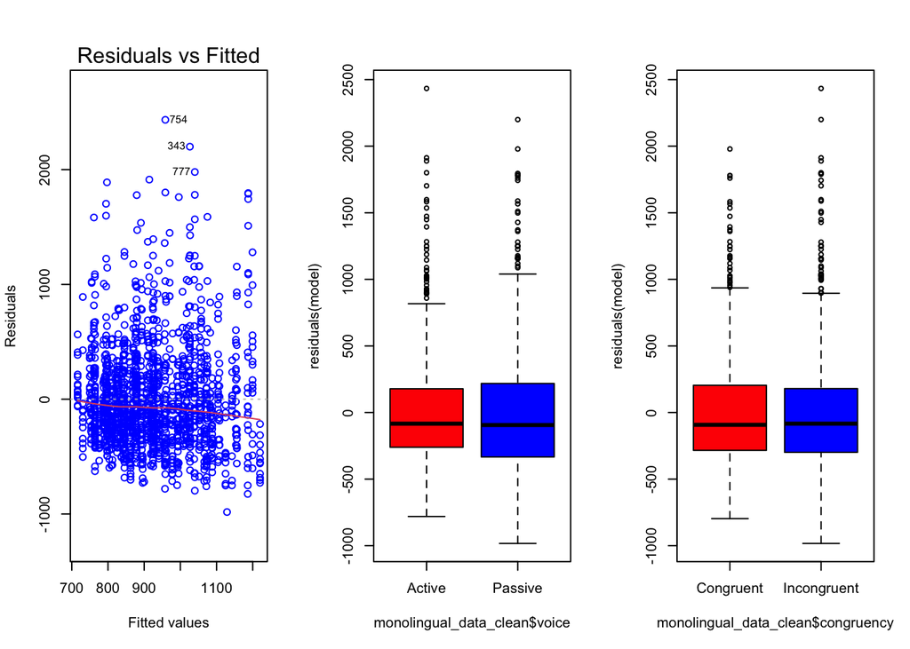

#### **2. Coefficients**

**A. The estimates** represent the mean change in the response variable for *one unit of change in the predictor variable while holding other predictors in the model constant.*

**B. The standard error (SE)** defines the accuracy of beta coefficients. For a given beta coefficient, the SE reflects how the coefficient varies under repeated sampling. It can be used to compute the confidence intervals (95%) and the **t-statistic**, where t = (b - 0)/SE(b).

**C. p-values** are our tests of significance and, together with the t-value, they tell us whether or not the beta coefficient of a predictor is *significantly different from zero*. The higher the t-statistic (2.00 or more) and the lower the p-value, the more significant the predictor

**But, what exactly is a p-value?**

The p-value is the *probability* of obtaining results at least as far away from the population mean as the observed results of a statistical hypothesis test, assuming that the *null hypothesis* is correct (0, no difference). In other words, a p-value is a measure of the probability that an observed difference could have occurred just by *random chance.*

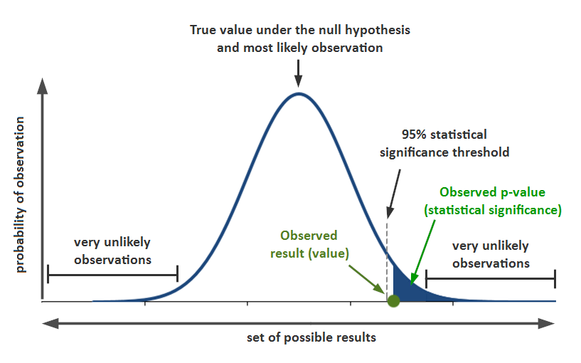

A confidence interval refers to the probability that a population parameter will fall between a set of values (-95%-95%) for a certain proportion of times.

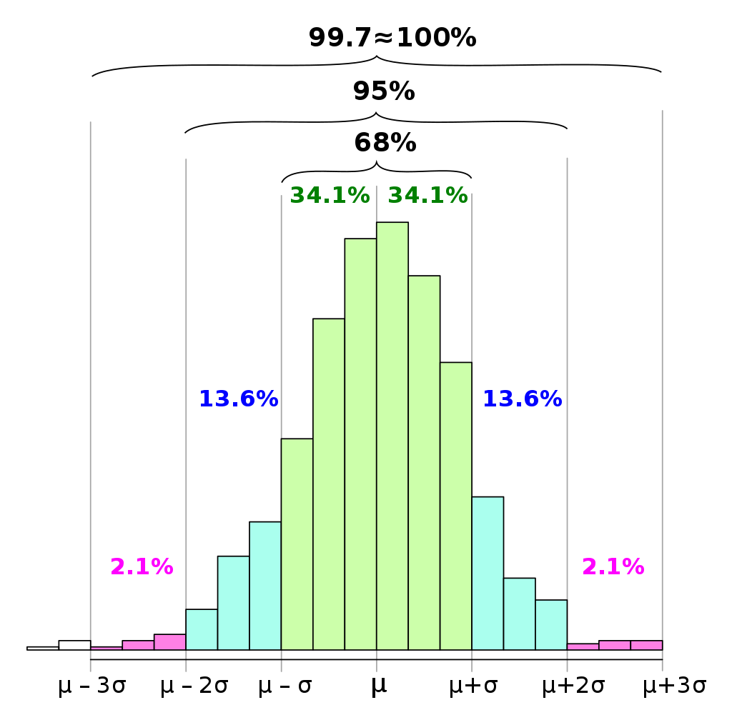

σ represents starndard deviations away from the mean, μ

Now, let’s read the estimates:

First, remember that, because of the way we coded the data (sum-contrasts), the **intercept** is *the grand mean across all conditions*.

```
## [1] 921.8249
```

Second, again because of the way we coded the data, we observe a significant **main effect of voice**. We obtain the beta coefficient in the model summary by subtracting the means for actives and passives. Therefore, for every 1 ms increase in RTs for the grand mean, we have a 170 ms increase in voice; the summary below indicates that this increase is driven by passives, as is to be expected given that passives have been shown to be read overall more slowly than actives.

```
## tibble [2 × 2] (S3: tbl_df/tbl/data.frame)
##  $ voice: chr [1:2] "Active" "Passive"
##  $ mean : num [1:2] 838 1008
```

```
## [1] 170
```

Third, we observe a significant **main effect of information status**. Again, we obtain the beta coefficient in the model summary by subtracting the means for given-new (congruent) and new-given (incongruent). Thus, for every 1 ms increase in RTs for the grand mean, we have a 91 ms increase in information structure; the summary below indicates that this increase is driven by new-given IS, as is to be expected given that new-given have been shown to be read overall more slowly than given-new.

```
## tibble [2 × 2] (S3: tbl_df/tbl/data.frame)
##  $ congruency: chr [1:2] "Congruent" "Incongruent"
##  $ mean      : num [1:2] 878 969
```

```
## [1] 91
```

Fourth, we observe a significant **main effect of proficiency**. For every 1 ms increase in RTs for the grand mean, we have a 62 ms increase in Picture Naming RTs, which entails that when participants named more slowly, their RTs across conditions where also slower.

Finally, we also observe an **interaction** between voice and information structure This entails that the effect of voice on total duration/RTs is different for the different levels of information structure First, let’s take a look at the means of the different conditions:

```
## tibble [4 × 2] (S3: tbl_df/tbl/data.frame)
##  $ condition: chr [1:4] "AAC" "API" "PAI" "PPC"
##  $ mean     : num [1:4] 821 1084 856 936
```

```
## [1] "AAC: active given-new, API: passive new-given, PAI: active new-given, PPC: passive given-new"
```

So, we observe that, in line with the previous main effects, it is passive + new-given that has the highest RTs and is, therefore, most probably driving the interaction. In order to assess this, we create two individual models to investigate the effect of information structure on actives and passives separately. For actives there is no effect of information structure:

```r
model_A <- lm(total ~ ccongruency, data = subset(monolingual_data_clean, voice == "Active"))
summary(model_A)
```

```
##
## Call:
## lm(formula = total ~ ccongruency, data = subset(monolingual_data_clean,
##     voice == "Active"))
##
## Residuals:
##    Min     1Q Median     3Q    Max
## -718.7 -273.7  -79.7  178.2 2536.3
##
## Coefficients:
##             Estimate Std. Error t value Pr(>|t|)
## (Intercept)   838.01      14.50  57.795   <2e-16 ***
## ccongruency    34.40      29.01   1.186    0.236
## ---
## Signif. codes:  0 '***' 0.001 '**' 0.01 '*' 0.05 '.' 0.1 ' ' 1
##
## Residual standard error: 414.7 on 816 degrees of freedom
## Multiple R-squared:  0.00172,    Adjusted R-squared:  0.0004965
## F-statistic: 1.406 on 1 and 816 DF,  p-value: 0.2361
```

However, the effect is significant in passives:

```r
model_P <- lm(total ~ ccongruency, data = subset(monolingual_data_clean, voice == "Passive"))
summary(model_P)
```

```
##
## Call:
## lm(formula = total ~ ccongruency, data = subset(monolingual_data_clean,
##     voice == "Passive"))
##
## Residuals:
##    Min     1Q Median     3Q    Max
## -938.0 -336.9  -98.3  207.9 2142.0
##
## Coefficients:
##             Estimate Std. Error t value Pr(>|t|)
## (Intercept)  1007.69      16.84  59.825  < 2e-16 ***
## ccongruency   148.35      33.70   4.402 1.22e-05 ***
## ---
## Signif. codes:  0 '***' 0.001 '**' 0.01 '*' 0.05 '.' 0.1 ' ' 1
##
## Residual standard error: 475.8 on 796 degrees of freedom
## Multiple R-squared:  0.02377,    Adjusted R-squared:  0.02254
## F-statistic: 19.38 on 1 and 796 DF,  p-value: 1.219e-05
```

#### **3.Model accuracy a.k.a Goodness-of-fit**

##### **A. Residual Standard Error**

The RSE is the residual variation, representing the average variation of the observations points around the fitted regression line. It provides an absolute measure of patterns in the data that can’t be explained by the model.

##### **C. Adjusted R-squared**

- small, 0.10 – < 0.30
- medium, 0.30 – < 0.50
- large, ≥ 0.50

##### **D. F-statistic**

The F-statistic gives the overall significance of the model. It assesses whether at least one predictor variable has a non-zero coefficient.

There are other important metrics that are commonly used for model evaluation and selection. These are an unbiased estimate of the model prediction error. The lower these metrics, the better the model. Here, we will learn about **Akaike’s Information Criterion (AIC)**. The basic idea of AIC is to penalize the inclusion of additional variables to a model. It adds a penalty that increases the error when including additional terms

Using the `glance()` function in the package `broom` we can obtain many measures of accuracy and validation from our model.

```r
library(broom)
glance(model)
```

```
## # A tibble: 1 x 11
##   r.squared adj.r.squared sigma statistic  p.value    df  logLik    AIC    BIC
##       <dbl>         <dbl> <dbl>     <dbl>    <dbl> <int>   <dbl>  <dbl>  <dbl>
## 1    0.0667        0.0644  442.      28.8 3.75e-23     5 -12133. 24278. 24310.
## # … with 2 more variables: deviance <dbl>, df.residual <int>
```

AIC is especially useful when *comparing models*; say, for example, that we want to know if including the interaction between voice and information structure truly improves the predictive power of our model. First, let’s create a model *without* the interaction. We see that this model has a slightly higher AIC, indicating low predictive power.

```r
model_NI <- lm(total ~ cvoice + ccongruency + scale(BPN_RT), data=monolingual_data_clean)
summary(model_NI)
```

```
##
## Call:
## lm(formula = total ~ cvoice + ccongruency + scale(BPN_RT), data = monolingual_data_clean)
##
## Residuals:
##     Min      1Q  Median      3Q     Max
## -953.28 -292.75  -87.67  198.70 2404.59
##
## Coefficients:
##               Estimate Std. Error t value Pr(>|t|)
## (Intercept)     921.82      11.01  83.743  < 2e-16 ***
## cvoice          170.40      22.02   7.739 1.75e-14 ***
## ccongruency      89.78      22.03   4.076 4.80e-05 ***
## scale(BPN_RT)    62.01      11.01   5.631 2.11e-08 ***
## ---
## Signif. codes:  0 '***' 0.001 '**' 0.01 '*' 0.05 '.' 0.1 ' ' 1
##
## Residual standard error: 442.5 on 1612 degrees of freedom
## Multiple R-squared:  0.06285,    Adjusted R-squared:  0.06111
## F-statistic: 36.04 on 3 and 1612 DF,  p-value: < 2.2e-16
```

```r
glance(model_NI)
```

```
## # A tibble: 1 x 11
##   r.squared adj.r.squared sigma statistic  p.value    df  logLik    AIC    BIC
##       <dbl>         <dbl> <dbl>     <dbl>    <dbl> <int>   <dbl>  <dbl>  <dbl>
## 1    0.0629        0.0611  443.      36.0 1.54e-22     4 -12136. 24283. 24310.
## # … with 2 more variables: deviance <dbl>, df.residual <int>
```

In addition, we can use the `anova()` function to compare model 1 to model 2. The analysis shows that model 1 is significantly better.

```r
anova(model, model_NI)
```

```
## Analysis of Variance Table
##
## Model 1: total ~ cvoice * ccongruency + scale(BPN_RT)
## Model 2: total ~ cvoice + ccongruency + scale(BPN_RT)
##   Res.Df       RSS Df Sum of Sq      F   Pr(>F)
## 1   1611 314340046
## 2   1612 315651478 -1  -1311431 6.7211 0.009614 **
## ---
## Signif. codes:  0 '***' 0.001 '**' 0.01 '*' 0.05 '.' 0.1 ' ' 1
```

#### Resources

- Readings
  - This corresponds to Andy Fields’ book Chapters 5 and 7,
  - This corresponds to Levshina’s book Chapter 7.
  - Altman & Krzywinski (2015) Simple linear regression
  - Gries (2013) Statistics for Linguistics with R: A Practical Introduction
- Regression
  - http://www.sthda.com/english/articles/40-regression-analysis/167-simple-linear-regression-in-r
  - https://blog.minitab.com/blog/adventures-in-statistics-2/regression-analysis-how-do-i-interpret-r-squared-and-assess-the-goodness-of-fit
  - https://feliperego.github.io/blog/2015/10/23/Interpreting-Model-Output-In-R
  - https://www.theanalysisfactor.com/interpreting-regression-coefficients/
- Assumptions
  - http://www.sthda.com/english/articles/39-regression-model-diagnostics/161-linear-regression-assumptions-and-diagnostics-in-r-essentials/
  - https://www.jmp.com/en_us/statistics-knowledge-portal/what-is-regression/simple-linear-regression-assumptions.html
- Factor coding
  - https://www.statisticssolutions.com/dummy-coding-the-how-and-why/
  - https://conjointly.com/kb/dummy-variables/
  - https://it.unt.edu/sites/default/files/categoricalregression_jds_june2010.pdf
  - https://talklab.psy.gla.ac.uk/tvw/catpred/

*Centering + https://www.theanalysisfactor.com/center-on-the-mean/

- Scaling
  - http://stattips.blogspot.com/2009/08/rescaling-continuous-predictors-in.html
  - https://benwhalley.github.io/just-enough-r/scaling-predictors.html
- p-value
  - https://blog.minitab.com/blog/adventures-in-statistics-2/how-to-correctly-interpret-p-values
  - https://www.investopedia.com/terms/p/p-value.asp#:~:text=In%20statistics%2C%20the%20p%2Dvalue,the%20null%20hypothesis%20is%20correct.&text=A%20smaller%20p%2Dvalue%20means,favor%20of%20the%20alternative%20hypothesis.
- Residuals
  - https://blog.minitab.com/blog/adventures-in-statistics-2/why-you-need-to-check-your-residual-plots-for-regression-analysis